# Windows_exposure

Yanelli Nunez

08/05/2021

Objective: - To select the months of exposure that follow within the exposure windows periods (1, 5, and 10 years pre-hospitalization). This is done in the individual level and years are estimated from diagnosis date.

- We also set some criteria for the cases/controls that should be included in the analysis. More details about this are presented below.

***Note, I re-run all code to remove the G12.2A:F subcategories but didn’t update the numbers in the notes below. The numbers remain pretty similar though

## 1. load merged patient/pollution dataset

```r
full_dataset <- readRDS(paste0(yanelli_datasets, "joined_datasets.rds")) # this is a large dataset

summary(full_dataset)
```

```
##        nr           lobnr             ck           diagtype
##  Min.   :   2   Min.   :0.000   Min.   :0.000   Min.   :1
##  1st Qu.:1330   1st Qu.:1.000   1st Qu.:0.000   1st Qu.:1
##  Median :2641   Median :2.000   Median :0.000   Median :1
##  Mean   :2540   Mean   :2.497   Mean   :0.167   Mean   :1
##  3rd Qu.:3831   3rd Qu.:4.000   3rd Qu.:0.000   3rd Qu.:1
##  Max.   :4608   Max.   :5.000   Max.   :1.000   Max.   :1
##
##     diagdat              year_gap             one_year
##  Min.   :1989-01-02   Min.   :1988-01-02   Min.   :1987-01-02
##  1st Qu.:2000-02-11   1st Qu.:1999-02-10   1st Qu.:1998-02-10
##  Median :2006-02-28   Median :2005-02-28   Median :2004-02-28
##  Mean   :2004-12-09   Mean   :2003-12-07   Mean   :2002-12-07
##  3rd Qu.:2010-05-26   3rd Qu.:2009-05-20   3rd Qu.:2008-05-20
##  Max.   :2013-12-30   Max.   :2012-12-30   Max.   :2011-12-30
##                       NA's   :7137         NA's   :7137
##    five_years           ten_years                ID         aegtesocial
##  Min.   :1983-01-02   Min.   :1978-01-02   Min.   :    9   Min.   :1.0
##  1st Qu.:1994-02-10   1st Qu.:1989-02-10   1st Qu.:10619   1st Qu.:3.0
##  Median :2000-02-28   Median :1995-02-28   Median :21102   Median :4.0
##  Mean   :1998-12-07   Mean   :1993-12-06   Mean   :20289   Mean   :5.2
##  3rd Qu.:2004-05-20   3rd Qu.:1999-05-20   3rd Qu.:30606   3rd Qu.:9.0
##  Max.   :2007-12-30   Max.   :2002-12-30   Max.   :36806   Max.   :9.0
##  NA's   :7137         NA's   :7137                         NA's   :753731
##      bdate                civst         civstdat5             d_inddto
##  Min.   :1901-02-06   Min.   :1.000   Min.   :1900-07-01   Min.   :1989-01-02
##  1st Qu.:1929-11-02   1st Qu.:2.000   1st Qu.:1962-07-21   1st Qu.:2000-02-15
##  Median :1938-12-01   Median :4.000   Median :1975-05-03   Median :2006-03-08
##  Mean   :1939-04-18   Mean   :3.243   Mean   :1976-06-24   Mean   :2004-12-17
##  3rd Qu.:1947-05-02   3rd Qu.:4.000   3rd Qu.:1991-05-08   3rd Qu.:2010-06-28
##  Max.   :1987-06-01   Max.   :4.000   Max.   :2013-08-30   Max.   :2013-12-30
##                       NA's   :1105    NA's   :654390
##     d_uddto              daars1             daars2              diag
##  Min.   :1989-01-06   Length:6824485     Length:6824485     34809 : 411292
##  1st Qu.:2000-07-11   Class :character   Class :character   DG122 :5516319
##  Median :2006-10-02   Mode  :character   Mode  :character   DG122G: 896874
##  Mean   :2005-06-24
##  3rd Qu.:2011-01-10
##  Max.   :2014-11-01
##
```

[output cut: 33 more lines]

```
##  Min.   :  1.572   Min.   :  90.16   Min.   : 0.0289   Min.   :  0.4666
##  1st Qu.: 11.177   1st Qu.: 188.00   1st Qu.: 0.5509   1st Qu.: 14.1036
##  Median : 14.483   Median : 244.98   Median : 0.8061   Median : 19.1747
##  Mean   : 15.146   Mean   : 282.10   Mean   : 0.9475   Mean   : 20.3904
##  3rd Qu.: 18.059   3rd Qu.: 321.75   3rd Qu.: 1.1712   3rd Qu.: 24.9798
##  Max.   :102.817   Max.   :3398.74   Max.   :15.4809   Max.   :100.3371
##  NA's   :1588      NA's   :1588      NA's   :1588      NA's   :1588
##     NOX_str             O3_str            PM10_str
##  Min.   :  0.5487   Min.   :  0.3113   Min.   :  3.986
##  1st Qu.: 16.3508   1st Qu.: 35.9593   1st Qu.: 17.289
##  Median : 23.9418   Median : 50.4164   Median : 20.593
##  Mean   : 30.5233   Mean   : 50.4862   Mean   : 21.315
##  3rd Qu.: 35.1751   3rd Qu.: 65.2591   3rd Qu.: 24.551
##  Max.   :515.6581   Max.   :144.9146   Max.   :123.447
##  NA's   :1588       NA's   :1588       NA's   :1588
```

```r
select_dataset <- full_dataset %>%
    drop_na(civst) %>%
  dplyr::filter(residence != "Greenland",
                residence != "Unknown") # remove greenland residents

case_num <- select_dataset %>%
  dplyr::filter(ck == 1) %>% # selecting only cases
  count(nr) # count number of unique "nr" (cases)

control_num <- select_dataset %>%
 dplyr::filter(ck == 0) %>% # selecting controls
  group_by(nr) %>%
   count(lobnr)
```

## 2. Nest data by cases

This allow us to more easily create windows of exposure for each case

```r
# a data set made up of sub-dataset. Each data subset corresponds to a patient and his/her controls
nested_data <- select_dataset %>%
  mutate(nr = as.factor(nr),
         lobnr = as.factor(lobnr),
         ck = as.factor(ck)) %>%
  group_by(nr) %>%
  nest()

summary(nested_data)
```

```
##        nr       data.Length  data.Class  data.Mode
##  2      :   1   40      tbl_df  list
##  3      :   1   40      tbl_df  list
##  4      :   1   40      tbl_df  list
##  5      :   1   40      tbl_df  list
##  6      :   1   40      tbl_df  list
##  7      :   1   40      tbl_df  list
##  (Other):3977   40      tbl_df  list
##                 40      tbl_df  list
##                 40      tbl_df  list
##                 40      tbl_df  list
##                 40      tbl_df  list
##                 40      tbl_df  list
##                 40      tbl_df  list
##                 40      tbl_df  list
```

[output cut: 3969 more lines]

```r
### take a look in a single case and corresponding controls
test <- as.data.frame(nested_data$data[[1]]) %>%
 dplyr::filter(date_exp <= year_gap & date_exp >= one_year)

summary(test)
```

```
##  lobnr  ck        diagtype    diagdat              year_gap
##  0:12   0:60   Min.   :1   Min.   :1993-02-22   Min.   :1992-02-22
##  1:12   1:12   1st Qu.:1   1st Qu.:1993-02-22   1st Qu.:1992-02-22
##  2:12          Median :1   Median :1993-02-22   Median :1992-02-22
##  3:12          Mean   :1   Mean   :1993-02-22   Mean   :1992-02-22
##  4:12          3rd Qu.:1   3rd Qu.:1993-02-22   3rd Qu.:1992-02-22
##  5:12          Max.   :1   Max.   :1993-02-22   Max.   :1992-02-22
##     one_year            five_years           ten_years                ID
##  Min.   :1991-02-22   Min.   :1987-02-22   Min.   :1982-02-22   Min.   : 9.0
##  1st Qu.:1991-02-22   1st Qu.:1987-02-22   1st Qu.:1982-02-22   1st Qu.:10.0
##  Median :1991-02-22   Median :1987-02-22   Median :1982-02-22   Median :11.5
##  Mean   :1991-02-22   Mean   :1987-02-22   Mean   :1982-02-22   Mean   :11.5
##  3rd Qu.:1991-02-22   3rd Qu.:1987-02-22   3rd Qu.:1982-02-22   3rd Qu.:13.0
##  Max.   :1991-02-22   Max.   :1987-02-22   Max.   :1982-02-22   Max.   :14.0
##   aegtesocial        bdate                civst     civstdat5
##  Min.   :2.000   Min.   :1929-01-01   Min.   :4   Min.   :1952-09-20
##  1st Qu.:2.000   1st Qu.:1929-03-01   1st Qu.:4   1st Qu.:1952-11-02
##  Median :5.000   Median :1929-04-16   Median :4   Median :1954-07-13
##  Mean   :5.333   Mean   :1929-04-26   Mean   :4   Mean   :1954-08-03
##  3rd Qu.:9.000   3rd Qu.:1929-07-01   3rd Qu.:4   3rd Qu.:1954-09-25
##  Max.   :9.000   Max.   :1929-09-01   Max.   :4   Max.   :1958-03-09
##     d_inddto             d_uddto              daars1
##  Min.   :1993-02-22   Min.   :1993-03-03   Length:72
##  1st Qu.:1993-02-22   1st Qu.:1993-03-03   Class :character
##  Median :1993-02-22   Median :1993-03-03   Mode  :character
##  Mean   :1993-02-22   Mean   :1993-03-03
##  3rd Qu.:1993-02-22   3rd Qu.:1993-03-03
##  Max.   :1993-02-22   Max.   :1993-03-03
##     daars2              diag         diy         family_SES       geokode
##  Length:72          34809 :72   Min.   :1993   Min.   :1.000   Min.   :3.000
##  Class :character   DG122 : 0   1st Qu.:1993   1st Qu.:2.000   1st Qu.:4.000
##  Mode  :character   DG122G: 0   Median :1993   Median :4.000   Median :7.000
##                                 Mean   :1993   Mean   :3.167   Mean   :6.167
##                                 3rd Qu.:1993   3rd Qu.:4.000   3rd Qu.:7.000
##                                 Max.   :1993   Max.   :4.000   Max.   :9.000
##      mynkod     pattype     postnr          sex        social
##  Min.   : 561   1:72    Min.   :3450   Min.   :1   Min.   :1.0
##  1st Qu.:7578   2: 0    1st Qu.:5250   1st Qu.:1   1st Qu.:4.0
##  Median :7763   3: 0    Median :6276   Median :1   Median :4.0
##  Mean   :6710           Mean   :6292   Mean   :1   Mean   :3.5
```

[output cut: 15 more lines]

```
##                                 Max.   :1929   Max.   :1992-02-01
##     PM25_str          CO_str          EC_str          NO2_str
##  Min.   : 6.879   Min.   :152.8   Min.   :0.3554   Min.   : 9.555
##  1st Qu.:13.581   1st Qu.:213.2   1st Qu.:0.6617   1st Qu.:18.084
##  Median :15.522   Median :263.2   Median :0.8809   Median :20.960
##  Mean   :15.955   Mean   :272.1   Mean   :0.9352   Mean   :20.509
##  3rd Qu.:17.674   3rd Qu.:321.0   3rd Qu.:1.1395   3rd Qu.:23.115
##  Max.   :28.312   Max.   :436.8   Max.   :2.0307   Max.   :29.406
##     NOX_str          O3_str         PM10_str
##  Min.   :10.81   Min.   :24.41   Min.   :11.85
##  1st Qu.:24.71   1st Qu.:37.31   1st Qu.:19.87
##  Median :29.53   Median :45.51   Median :22.76
##  Mean   :29.94   Mean   :49.14   Mean   :22.99
##  3rd Qu.:34.65   3rd Qu.:62.11   3rd Qu.:26.20
##  Max.   :52.61   Max.   :72.10   Max.   :37.12
```

## 3. Select exposure within window of exposure period

- For each case, select years within exposure window of 1, 5, and 10 years pre-hospitalization with a 1-year gap between start of exposure and first hospitalization

```r
# filter data for the 1, 5 and 10 year periods

filtered_data <- nested_data %>%
  mutate(one_year = purrr::map(data, ~ dplyr::filter(.x, date_exp <= year_gap & date_exp > one_year)),
         five_yr = purrr::map(data, ~ dplyr::filter(.x, date_exp <= year_gap & date_exp > five_years)),
         ten_yr = purrr::map(data, ~ dplyr::filter(.x, date_exp <= year_gap & date_exp > ten_years)))

# explore a random dataset within the list of datasets to make sure it looks right
explore <- filtered_data$one_year[[1]]
summary(explore)
```

```
##  lobnr  ck        diagtype    diagdat              year_gap
##  0:12   0:60   Min.   :1   Min.   :1993-02-22   Min.   :1992-02-22
##  1:12   1:12   1st Qu.:1   1st Qu.:1993-02-22   1st Qu.:1992-02-22
##  2:12          Median :1   Median :1993-02-22   Median :1992-02-22
##  3:12          Mean   :1   Mean   :1993-02-22   Mean   :1992-02-22
##  4:12          3rd Qu.:1   3rd Qu.:1993-02-22   3rd Qu.:1992-02-22
##  5:12          Max.   :1   Max.   :1993-02-22   Max.   :1992-02-22
##     one_year            five_years           ten_years                ID
##  Min.   :1991-02-22   Min.   :1987-02-22   Min.   :1982-02-22   Min.   : 9.0
##  1st Qu.:1991-02-22   1st Qu.:1987-02-22   1st Qu.:1982-02-22   1st Qu.:10.0
##  Median :1991-02-22   Median :1987-02-22   Median :1982-02-22   Median :11.5
##  Mean   :1991-02-22   Mean   :1987-02-22   Mean   :1982-02-22   Mean   :11.5
##  3rd Qu.:1991-02-22   3rd Qu.:1987-02-22   3rd Qu.:1982-02-22   3rd Qu.:13.0
##  Max.   :1991-02-22   Max.   :1987-02-22   Max.   :1982-02-22   Max.   :14.0
##   aegtesocial        bdate                civst     civstdat5
##  Min.   :2.000   Min.   :1929-01-01   Min.   :4   Min.   :1952-09-20
##  1st Qu.:2.000   1st Qu.:1929-03-01   1st Qu.:4   1st Qu.:1952-11-02
##  Median :5.000   Median :1929-04-16   Median :4   Median :1954-07-13
##  Mean   :5.333   Mean   :1929-04-26   Mean   :4   Mean   :1954-08-03
##  3rd Qu.:9.000   3rd Qu.:1929-07-01   3rd Qu.:4   3rd Qu.:1954-09-25
##  Max.   :9.000   Max.   :1929-09-01   Max.   :4   Max.   :1958-03-09
##     d_inddto             d_uddto              daars1
##  Min.   :1993-02-22   Min.   :1993-03-03   Length:72
##  1st Qu.:1993-02-22   1st Qu.:1993-03-03   Class :character
##  Median :1993-02-22   Median :1993-03-03   Mode  :character
##  Mean   :1993-02-22   Mean   :1993-03-03
##  3rd Qu.:1993-02-22   3rd Qu.:1993-03-03
##  Max.   :1993-02-22   Max.   :1993-03-03
##     daars2              diag         diy         family_SES       geokode
##  Length:72          34809 :72   Min.   :1993   Min.   :1.000   Min.   :3.000
##  Class :character   DG122 : 0   1st Qu.:1993   1st Qu.:2.000   1st Qu.:4.000
##  Mode  :character   DG122G: 0   Median :1993   Median :4.000   Median :7.000
##                                 Mean   :1993   Mean   :3.167   Mean   :6.167
##                                 3rd Qu.:1993   3rd Qu.:4.000   3rd Qu.:7.000
##                                 Max.   :1993   Max.   :4.000   Max.   :9.000
##      mynkod     pattype     postnr          sex        social
##  Min.   : 561   1:72    Min.   :3450   Min.   :1   Min.   :1.0
##  1st Qu.:7578   2: 0    1st Qu.:5250   1st Qu.:1   1st Qu.:4.0
##  Median :7763   3: 0    Median :6276   Median :1   Median :4.0
##  Mean   :6710           Mean   :6292   Mean   :1   Mean   :3.5
```

[output cut: 15 more lines]

```
##                                 Max.   :1929   Max.   :1992-02-01
##     PM25_str          CO_str          EC_str          NO2_str
##  Min.   : 6.879   Min.   :152.8   Min.   :0.3554   Min.   : 9.555
##  1st Qu.:13.581   1st Qu.:213.2   1st Qu.:0.6617   1st Qu.:18.084
##  Median :15.522   Median :263.2   Median :0.8809   Median :20.960
##  Mean   :15.955   Mean   :272.1   Mean   :0.9352   Mean   :20.509
##  3rd Qu.:17.674   3rd Qu.:321.0   3rd Qu.:1.1395   3rd Qu.:23.115
##  Max.   :28.312   Max.   :436.8   Max.   :2.0307   Max.   :29.406
##     NOX_str          O3_str         PM10_str
##  Min.   :10.81   Min.   :24.41   Min.   :11.85
##  1st Qu.:24.71   1st Qu.:37.31   1st Qu.:19.87
##  Median :29.53   Median :45.51   Median :22.76
##  Mean   :29.94   Mean   :49.14   Mean   :22.99
##  3rd Qu.:34.65   3rd Qu.:62.11   3rd Qu.:26.20
##  Max.   :52.61   Max.   :72.10   Max.   :37.12
```

## 4. Explore missing data

### 4a. One-year exposure window

Notes:

1. In the original dataset there is a total of 4,011 cases. If each case has 5 controls then there should be a total of 20,055 controls, that is, 24,066 net total.
2. The one-year window of exposure has a total of 23,732 case/controls with a **total of 3,952 cases** specifically and *19,780 controls*. This means **59 cases** from the original data have zero observations during this year. That is, the data is missing *1.5%* of cases from the original dataset
3. Overall 93 out of 23,732 cases/controls **(0.39%)** are missing one or more of the 12 months for the one year exposure window

Notes:

```r
one_year <- filtered_data %>%
  dplyr::select(-data, -five_yr, -ten_yr) %>%
  unnest(., cols = one_year)

# check how many cases and controls total we have in this data set
case_num <- one_year %>%
  dplyr::filter(ck == 1) %>% # selecting only cases
  count(nr) # count number of unique "nr" (cases)

control_num <- one_year %>%
 dplyr::filter(ck == 0) %>% # selecting controls
  group_by(nr) %>%
   count(lobnr)

# check how many cases/controls are missing months
exp_missing <- one_year %>%
 group_by(nr, lobnr) %>%
  summarise(counts = n()) # lowest number of months measure for a given case or control is 1
exp_missing %>%
  tally(counts<12) %>%
  summarize(n=sum(n))
```

```
## # A tibble: 1 x 1
##       n
##   <int>
## 1    81
```

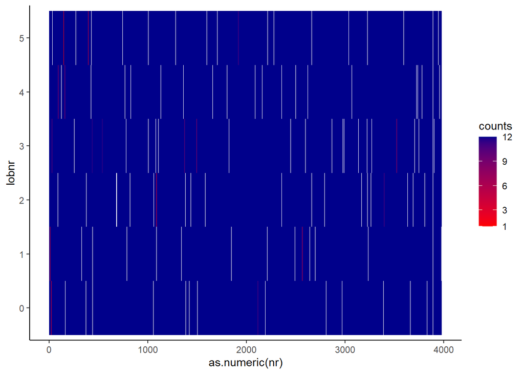

```r
# heat map to visualize missingness
exp_missing %>% ggplot(aes(as.numeric(nr), lobnr, fill= counts)) +
  geom_tile() +
  theme_classic() +
  scale_fill_gradient('counts', limits=c(1, 12), breaks = c(1, 3, 6, 9, 12),  low = "red", high = "darkblue")
```

## 4b. 5-year exposure window

Notes:

```r
# select the 5-years time window dataset
five_years <- filtered_data %>%
  dplyr::select(-data, -one_year, -ten_yr) %>%
  unnest(., cols = five_yr)

# check how many cases total we have in this dataset
case_num_5 <- five_years %>%
 dplyr::filter(ck == 1) %>% # selecting only cases
  count(nr) # count number of unique "nr" (cases)

# check how many controls total we have in this dataset
control_num_5 <- five_years %>%
  dplyr::filter(ck == 0) %>% # selecting controls
  group_by(nr) %>%
   count(lobnr)

# check how many cases/controls are missing months
exp_missing_5yrs <- five_years %>%
  group_by(nr, lobnr) %>%
  summarise(counts = n()) # minimum number of available months is 1
exp_missing_5yrs %>%
  tally(counts<60) %>%
  summarize(n=sum(n))
```

```
## # A tibble: 1 x 1
##       n
##   <int>
## 1   390
```

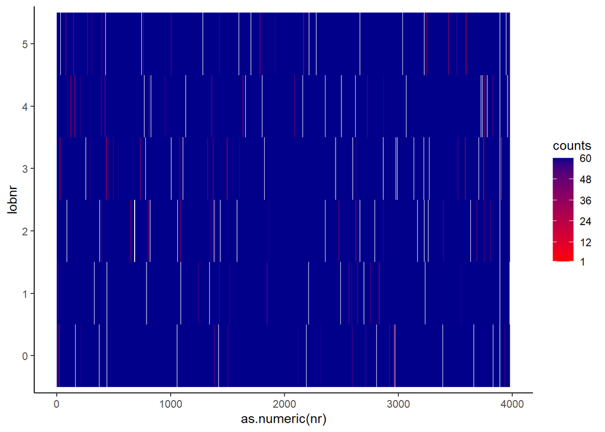

```r
# heat map to visualize missingness
exp_missing_5yrs %>% ggplot(aes(as.numeric(nr), lobnr, fill= counts)) +
  geom_tile() +
  theme_classic() +
  scale_fill_gradient('counts', limits=c(1, 60), breaks = c(1, 12, 24, 36, 48, 60),  low = "red", high = "darkblue")
```

## 4c. 10-year exposure window

Notes:

1. In the original dataset there is a total of 4,011 cases. If case has 5 controls then there should be a total of 20,055 controls, that is, 24,066 net total
2. The 10-year window of exposure has a total of 23,848 cases/controls. Specifically, it has **3,974 cases** and *19,874 controls*. This means **37 cases** from the original data have zero observations during this 10-year time period. That is, the data is missing *0.9%* of cases from the original dataset
3. 1284 out of 23,848 cases/controls **(~5%)** are missing one or more of the 120 months of the 10-year exposure period

```r
# select the ten-years time window dataset
ten_years <- filtered_data %>%
  dplyr::select(-data, -one_year, -five_yr) %>%
  unnest(., cols = ten_yr)

# check how many cases total we have in this dataset
case_num_10 <- ten_years %>%
 dplyr::filter(ck == 1) %>% # selecting only cases
  count(nr) # count number of unique "nr" (cases)

# check how many controls total we have in this dataset
control_num_10 <- ten_years %>%
  dplyr::filter(ck == 0) %>% # selecting controls
  group_by(nr) %>%
   count(lobnr)

# check how many cases/controls are missing months
exp_missing_10yrs <- ten_years %>%
  group_by(nr, lobnr) %>%
  summarise(counts = n()) # minimum number of available months is 1
exp_missing_10yrs %>%
  tally(counts<120) %>%
  summarize(n=sum(n))
```

```
## # A tibble: 1 x 1
##       n
##   <int>
## 1  1216
```

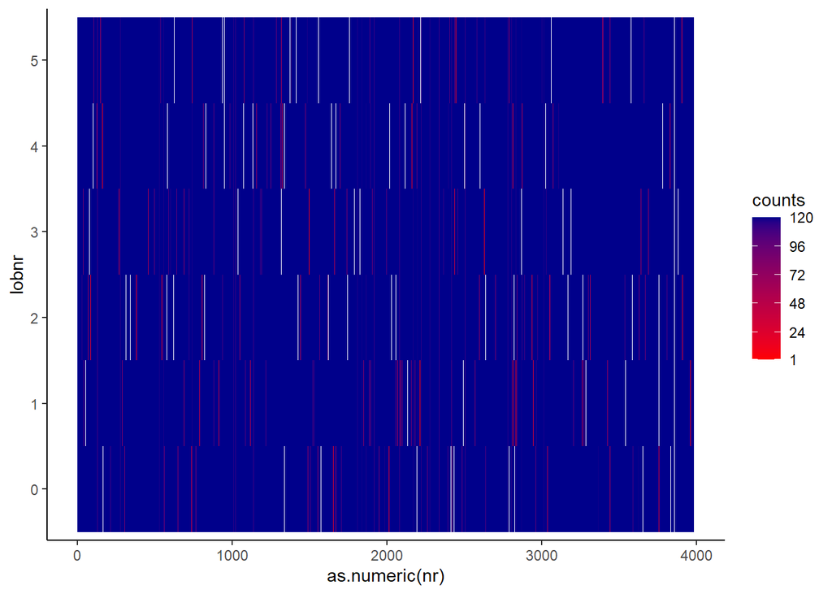

```r
# heat map to visualize missingness
exp_missing_10yrs %>% ggplot(aes(as.numeric(nr), lobnr, fill= counts)) + geom_tile() +
  #scale_fill_continuous(limits=c(0, 12), breaks=seq(0,12, by=1)) +
  #scale_fill_viridis(limits = c(0, 60), discrete=FALSE) +
  theme_classic() +
  scale_fill_gradient('counts', limits=c(1, 120), breaks = c(1, 24, 48, 72, 96, 120),  low = "red", high = "darkblue")
```

## 5. Data selection

Criteria:

For the 1-year exposure window, limit cases and controls to those we have at least 75% of the pollutant measurements. That is, at least **9 out of the 12 months** need to have a pollutant measurement. Furthermore, within those 9 measurements we need to have at least one measure for each of the year seasons (Denmark has 4 seasons)

For the 5-years and 10-years exposure window, limit cases and controls to those we have at least 50% of the PM2.5 measurements. That is, for the 5-year time window at least **30 out of the 60 months** should have a measurement. For the 10-year window, each case/control should have at least 60 months with pollutant measurements out of the 120 months.

For all time windows, each case needs to have at least one control that fulfills the requirements described in the above text.

### 5a. 1-year exposure windows

Notes:

- **3,942 cases and 19,406 controls total** after selecting only the data that meets the requirements described above Now each case should have at least one control and each entry should have pollutant measurements for at least 9 out of the 12 months and there should be at least one measurement in each of the four weather seasons

```r
filter_1yr <- one_year %>%
  group_by(nr, lobnr) %>%
  dplyr::mutate(months_meas = n()) %>%
  ungroup() %>%
  dplyr::filter(months_meas >= 9) %>% # select those with at least 9 months
  mutate(month_exp = month(date_exp),
         season = if_else(month_exp >=3 & month_exp <= 5, "spring",
                  if_else(month_exp >=6 & month_exp <=8, "summer",
                  if_else(month_exp >=9 & month_exp <= 11, "fall",
                  if_else(month_exp == 12 | month_exp <= 2, "winter", "x"))))) %>%  # season ID
  group_by(nr, lobnr) %>%
  mutate(season_num = length(unique(season))) %>% #XX entries are missing measurements in a season
ungroup() %>%
  dplyr::filter(season_num >= 4) %>% # filter for entries that have at least 1 measurement in each season
group_by(nr) %>%
  dplyr::mutate(case_control = length(unique(ck))) %>% # ID to check that each case has at least one control and that each control has a case
  dplyr::filter(case_control >= 2) %>% # filter cases that have  at least  one  control  and controls that have a  case
  ungroup() %>%
  dplyr::select(-month_exp, -months_meas, -season, -season_num, -case_control) # remove IDs

summary(filter_1yr)
```

```
##        nr         lobnr     ck            diagtype    diagdat
##  2      :    72   0:46911   0:230343   Min.   :1   Min.   :1989-01-02
##  3      :    72   1:46212   1: 46911   1st Qu.:1   1st Qu.:1997-05-21
##  4      :    72   2:45988              Median :1   Median :2003-10-30
##  5      :    72   3:45998              Mean   :1   Mean   :2003-01-30
##  6      :    72   4:46064              3rd Qu.:1   3rd Qu.:2009-02-05
##  7      :    72   5:46081              Max.   :1   Max.   :2013-12-30
##  (Other):276822
##     year_gap             one_year            five_years
##  Min.   :1988-01-02   Min.   :1987-01-02   Min.   :1983-01-02
##  1st Qu.:1996-05-21   1st Qu.:1995-05-21   1st Qu.:1991-05-21
##  Median :2002-10-30   Median :2001-10-30   Median :1997-10-30
##  Mean   :2002-01-30   Mean   :2001-01-30   Mean   :1997-01-30
##  3rd Qu.:2008-02-05   3rd Qu.:2007-02-05   3rd Qu.:2003-02-05
##  Max.   :2012-12-30   Max.   :2011-12-30   Max.   :2007-12-30
##
##    ten_years                ID         aegtesocial        bdate
##  Min.   :1978-01-02   Min.   :    9   Min.   :1.000   Min.   :1901-02-06
##  1st Qu.:1986-05-21   1st Qu.: 9588   1st Qu.:3.000   1st Qu.:1927-04-02
##  Median :1992-10-30   Median :19069   Median :5.000   Median :1936-10-01
##  Mean   :1992-01-31   Mean   :18896   Mean   :5.294   Mean   :1937-05-29
##  3rd Qu.:1998-02-05   3rd Qu.:28475   3rd Qu.:9.000   3rd Qu.:1946-04-01
##  Max.   :2002-12-30   Max.   :36806   Max.   :9.000   Max.   :1987-06-01
##                                       NA's   :30768
##      civst         civstdat5             d_inddto             d_uddto
##  Min.   :1.000   Min.   :1900-07-01   Min.   :1989-01-02   Min.   :1989-01-06
##  1st Qu.:2.000   1st Qu.:1960-09-03   1st Qu.:1997-05-21   1st Qu.:1997-09-20
##  Median :4.000   Median :1973-04-02   Median :2003-11-03   Median :2004-04-23
##  Mean   :3.246   Mean   :1974-08-15   Mean   :2003-02-07   Mean   :2003-08-05
##  3rd Qu.:4.000   3rd Qu.:1989-06-24   3rd Qu.:2009-02-23   3rd Qu.:2009-09-22
##  Max.   :4.000   Max.   :2013-08-30   Max.   :2013-12-30   Max.   :2014-11-01
##                  NA's   :25424
##     daars1             daars2              diag             diy
##  Length:277254      Length:277254      34809 : 30501   Min.   :1989
##  Class :character   Class :character   DG122 :217252   1st Qu.:1997
##  Mode  :character   Mode  :character   DG122G: 29501   Median :2003
##                                                        Mean   :2003
##                                                        3rd Qu.:2009
##                                                        Max.   :2013
##
```

[output cut: 33 more lines]

```
##  Min.   : 0.03276   Min.   : 1.481   Min.   :  1.692   Min.   :  1.675
##  1st Qu.: 0.46547   1st Qu.:12.258   1st Qu.: 13.933   1st Qu.: 39.346
##  Median : 0.69268   Median :16.744   Median : 20.085   Median : 53.130
##  Mean   : 0.81437   Mean   :18.246   Mean   : 25.745   Mean   : 52.552
##  3rd Qu.: 1.01667   3rd Qu.:22.564   3rd Qu.: 29.866   3rd Qu.: 66.328
##  Max.   :10.44558   Max.   :93.179   Max.   :373.362   Max.   :117.169
##
##     PM10_str
##  Min.   : 5.693
##  1st Qu.:14.742
##  Median :17.624
##  Mean   :18.130
##  3rd Qu.:20.757
##  Max.   :57.628
##
```

```r
# final number of cases
filter_1yr %>%
 dplyr::filter(ck == 1) %>% # selecting only cases
  count(nr) %>%
  nrow()
```

```
## [1] 3910
```

```r
#final number of controls
filter_1yr %>%
  dplyr::filter(ck == 0) %>% #select controls only
  group_by(nr) %>%
 count(lobnr) %>%
  nrow()
```

```
## [1] 19199
```

```r
# save data
write_csv(filter_1yr, paste0(yanelli_datasets, "one_yr_filtered_data.csv"))
```

### 5b. 5-years exposure windows

Notes:

- **3,942 cases and 19,398 controls** total after selecting only the data that meets the requirements

```r
filter_5yrs <- five_years %>%
  group_by(nr, lobnr) %>%
  dplyr::mutate(months_meas = n()) %>% #ID to check mounts measure
  ungroup() %>%
  dplyr::filter(months_meas >= 30) %>% # select those with at least 30 months
group_by(nr) %>%
  dplyr::mutate(case_control = length(unique(ck))) %>% # ID to check that each case has at least one control and that each control has a case
  dplyr::filter(case_control >= 2) %>%
  ungroup() %>%
  dplyr::select(-case_control, -months_meas) # remove IDs

summary(filter_5yrs)
```

```
##        nr          lobnr      ck             diagtype    diagdat
##  2      :    360   0:233836   0:1146853   Min.   :1   Min.   :1989-01-02
##  3      :    360   1:230215   1: 233836   1st Qu.:1   1st Qu.:1997-05-27
##  4      :    360   2:229050               Median :1   Median :2003-11-14
##  5      :    360   3:228891               Mean   :1   Mean   :2003-02-07
##  6      :    360   4:229394               3rd Qu.:1   3rd Qu.:2009-02-09
##  7      :    360   5:229303               Max.   :1   Max.   :2013-12-30
##  (Other):1378529
##     year_gap             one_year            five_years
##  Min.   :1988-01-02   Min.   :1987-01-02   Min.   :1983-01-02
##  1st Qu.:1996-05-27   1st Qu.:1995-05-27   1st Qu.:1991-05-27
##  Median :2002-11-14   Median :2001-11-14   Median :1997-11-14
##  Mean   :2002-02-07   Mean   :2001-02-06   Mean   :1997-02-06
##  3rd Qu.:2008-02-09   3rd Qu.:2007-02-09   3rd Qu.:2003-02-09
##  Max.   :2012-12-30   Max.   :2011-12-30   Max.   :2007-12-30
##
##    ten_years                ID         aegtesocial         bdate
##  Min.   :1978-01-02   Min.   :    9   Min.   :1.00     Min.   :1901-02-06
##  1st Qu.:1986-05-27   1st Qu.: 9610   1st Qu.:3.00     1st Qu.:1927-04-02
##  Median :1992-11-14   Median :19068   Median :5.00     Median :1936-10-01
##  Mean   :1992-02-07   Mean   :18903   Mean   :5.29     Mean   :1937-06-01
##  3rd Qu.:1998-02-09   3rd Qu.:28491   3rd Qu.:9.00     3rd Qu.:1946-04-01
##  Max.   :2002-12-30   Max.   :36806   Max.   :9.00     Max.   :1987-06-01
##                                       NA's   :152404
##      civst         civstdat5             d_inddto             d_uddto
##  Min.   :1.000   Min.   :1900-07-01   Min.   :1989-01-02   Min.   :1989-01-06
##  1st Qu.:2.000   1st Qu.:1960-09-10   1st Qu.:1997-05-29   1st Qu.:1997-09-29
##  Median :4.000   Median :1973-04-07   Median :2003-11-20   Median :2004-05-11
##  Mean   :3.245   Mean   :1974-08-21   Mean   :2003-02-14   Mean   :2003-08-14
##  3rd Qu.:4.000   3rd Qu.:1989-06-24   3rd Qu.:2009-02-25   3rd Qu.:2009-10-06
##  Max.   :4.000   Max.   :2013-08-30   Max.   :2013-12-30   Max.   :2014-11-01
##                  NA's   :126386
##     daars1             daars2              diag              diy
##  Length:1380689     Length:1380689     34809 : 150823   Min.   :1989
##  Class :character   Class :character   DG122 :1082398   1st Qu.:1997
##  Mode  :character   Mode  :character   DG122G: 147468   Median :2003
##                                                         Mean   :2003
##                                                         3rd Qu.:2009
##                                                         Max.   :2013
##
```

[output cut: 33 more lines]

```
##  Min.   : 0.02886   Min.   : 1.084   Min.   :  1.166   Min.   :  1.005
##  1st Qu.: 0.48778   1st Qu.:12.806   1st Qu.: 14.612   1st Qu.: 38.363
##  Median : 0.72291   Median :17.484   Median : 21.213   Median : 52.339
##  Mean   : 0.85108   Mean   :18.921   Mean   : 27.216   Mean   : 51.929
##  3rd Qu.: 1.06046   3rd Qu.:23.300   3rd Qu.: 31.458   3rd Qu.: 65.980
##  Max.   :13.44768   Max.   :93.179   Max.   :373.362   Max.   :137.362
##
##     PM10_str
##  Min.   :  4.443
##  1st Qu.: 15.213
##  Median : 18.156
##  Mean   : 18.773
##  3rd Qu.: 21.501
##  Max.   :106.936
##
```

```r
# final number of cases
 filter_5yrs %>%
   dplyr::filter(ck == 1) %>% # selecting only cases
  count(nr) %>%
  nrow()
```

```
## [1] 3906
```

```r
#final number of controls
filter_5yrs %>%
  dplyr::filter(ck == 0) %>% #select controls only
  group_by(nr) %>%
 count(lobnr) %>%
  nrow()
```

```
## [1] 19157
```

```r
# save data
write_csv(filter_5yrs, paste0(yanelli_datasets, "five_yrs_filtered_data.csv"))
```

### 5c. 10-years exposure window

Notes: - **3,938 cases and 19,362 controls** total after selecting only the data that meets the requirements

```r
filter_10yrs <- ten_years %>%
  group_by(nr, lobnr) %>%
  dplyr::mutate(months_meas = n()) %>% #ID to check months measure
  ungroup() %>%
  dplyr::filter(months_meas >= 60) %>% # select those with at least 60 months
group_by(nr) %>%
  dplyr::mutate(case_control = length(unique(ck))) %>% # ID to check that each case has at least one control and that each control has a case
  dplyr::filter(case_control >= 2) %>%
  ungroup() %>%
  dplyr::select(-case_control, -months_meas) # remove ID

summary(filter_10yrs)
```

```
##        nr          lobnr      ck             diagtype    diagdat
##  2      :    720   0:465753   0:2281159   Min.   :1   Min.   :1989-01-02
##  3      :    720   1:457404   1: 465753   1st Qu.:1   1st Qu.:1997-06-07
##  4      :    720   2:455483               Median :1   Median :2003-11-17
##  5      :    720   3:455769               Mean   :1   Mean   :2003-02-12
##  6      :    720   4:456179               3rd Qu.:1   3rd Qu.:2009-02-11
##  7      :    720   5:456324               Max.   :1   Max.   :2013-12-30
##  (Other):2742592
##     year_gap             one_year            five_years
##  Min.   :1988-01-02   Min.   :1987-01-02   Min.   :1983-01-02
##  1st Qu.:1996-06-07   1st Qu.:1995-06-07   1st Qu.:1991-06-07
##  Median :2002-11-17   Median :2001-11-17   Median :1997-11-17
##  Mean   :2002-02-12   Mean   :2001-02-12   Mean   :1997-02-12
##  3rd Qu.:2008-02-11   3rd Qu.:2007-02-11   3rd Qu.:2003-02-11
##  Max.   :2012-12-30   Max.   :2011-12-30   Max.   :2007-12-30
##
##    ten_years                ID         aegtesocial         bdate
##  Min.   :1978-01-02   Min.   :    9   Min.   :1.00     Min.   :1901-02-06
##  1st Qu.:1986-06-07   1st Qu.: 9622   1st Qu.:3.00     1st Qu.:1927-04-02
##  Median :1992-11-17   Median :19059   Median :5.00     Median :1936-10-01
##  Mean   :1992-02-12   Mean   :18911   Mean   :5.29     Mean   :1937-05-31
##  3rd Qu.:1998-02-11   3rd Qu.:28497   3rd Qu.:9.00     3rd Qu.:1946-04-01
##  Max.   :2002-12-30   Max.   :36806   Max.   :9.00     Max.   :1987-06-01
##                                       NA's   :302687
##      civst         civstdat5             d_inddto             d_uddto
##  Min.   :1.000   Min.   :1900-07-01   Min.   :1989-01-02   Min.   :1989-01-06
##  1st Qu.:2.000   1st Qu.:1960-09-09   1st Qu.:1997-06-09   1st Qu.:1997-10-07
##  Median :4.000   Median :1973-03-28   Median :2003-11-23   Median :2004-05-11
##  Mean   :3.245   Mean   :1974-08-19   Mean   :2003-02-20   Mean   :2003-08-19
##  3rd Qu.:4.000   3rd Qu.:1989-06-22   3rd Qu.:2009-02-26   3rd Qu.:2009-10-12
##  Max.   :4.000   Max.   :2013-08-30   Max.   :2013-12-30   Max.   :2014-11-01
##                  NA's   :251965
##     daars1             daars2              diag              diy
##  Length:2746912     Length:2746912     34809 : 299394   Min.   :1989
##  Class :character   Class :character   DG122 :2152654   1st Qu.:1997
##  Mode  :character   Mode  :character   DG122G: 294864   Median :2003
##                                                         Mean   :2003
##                                                         3rd Qu.:2009
##                                                         Max.   :2013
##
```

[output cut: 33 more lines]

```
##  Min.   : 0.02886   Min.   : 1.084   Min.   :  1.166   Min.   :  0.6903
##  1st Qu.: 0.50978   1st Qu.:13.315   1st Qu.: 15.286   1st Qu.: 37.3288
##  Median : 0.75087   Median :18.162   Median : 22.303   Median : 51.6353
##  Mean   : 0.88623   Mean   :19.526   Mean   : 28.598   Mean   : 51.3421
##  3rd Qu.: 1.09948   3rd Qu.:24.009   3rd Qu.: 33.015   3rd Qu.: 65.7177
##  Max.   :15.48087   Max.   :99.953   Max.   :373.362   Max.   :144.9146
##
##     PM10_str
##  Min.   :  4.238
##  1st Qu.: 15.786
##  Median : 18.820
##  Mean   : 19.559
##  3rd Qu.: 22.451
##  Max.   :106.936
##
```

```r
# final number of cases
 filter_10yrs %>%
   dplyr::filter(ck == 1) %>% # selecting only cases
  count(nr) %>%
  nrow()
```

```
## [1] 3901
```

```r
#final number of controls
filter_10yrs %>%
 dplyr::filter(ck == 0) %>% #select controls only
  group_by(nr) %>%
 count(lobnr) %>%
  nrow()
```

```
## [1] 19108
```

```r
# save data
write_csv(filter_10yrs, paste0(yanelli_datasets, "ten_yrs_filtered_data.csv"))
```